# Data Manipulation and Visualiation Workshop Midwest Updated February 2023

### Faceting

You can facet figures which means it pulls apart the data in the figures based on some sort of factor. In these types of figures, comparison can be easier. We will use an example of faceting the bar plots by field station.

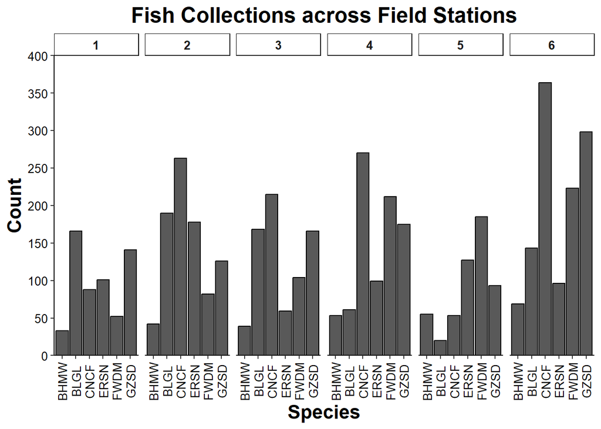

```r
ggplot(fish, aes(fishcode))+
  geom_bar(position="dodge", color="black")+
  ylab("Count")+
  xlab("Species")+
  ggtitle("Fish Collections across Field Stations")+
  scale_y_continuous(limits=c(0,400), breaks=seq(0,400,50), expand=c(0,0))+
  labs(fill="Field Station")+
theme(
    panel.background = element_blank(),
    axis.title.x = element_text(size=16, face="bold"),
    axis.title.y = element_text(size =16, face="bold"),
    plot.title = element_text(size=18, face="bold", hjust=0.5),
    axis.text = element_text(size=10, color="black"),
    axis.text.x=element_text(angle=90, vjust=.5),
    legend.text = element_text(size=8),
    legend.title = element_text(size=12),
    legend.position= "right",
    axis.line=element_line()
    )+
  facet_grid(. ~ fstation) + #add a facet graph, . ~ fstation will facet across the x-axis while fstation . ~ will facet across the y-axis
  #you can also use facet_wrap. Which is better for data with one variable you are faceting by. It will automatically create different columns and rows of data to best show your visualization
  theme(strip.text = element_text(face="bold", size=10), #change the text that labels the facets
        strip.background = element_rect(fill="white", color="black")) #change the box fill to white and the outline color to black of the boxes at the top of the figure
```

### Factor Reordering

GGplot automatically plots everything based on factors in alphabetical order. However, alphabetical order does not always make sense, so to combat this issue you can use a factor reorder to plot based on logic or another grouping.

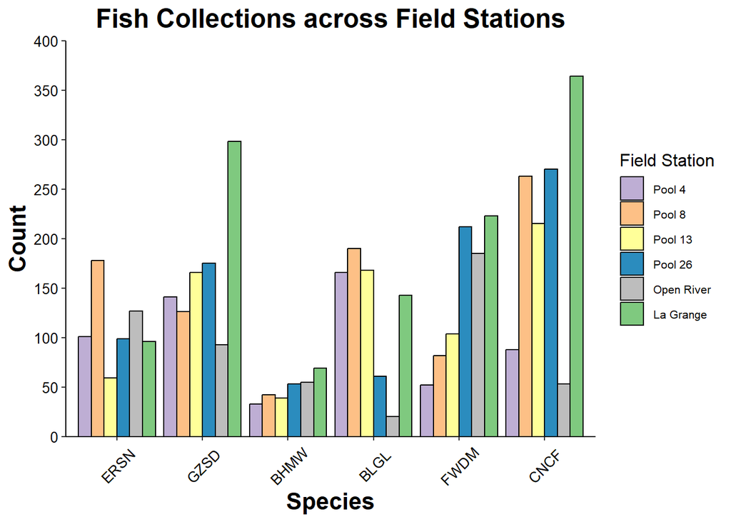

```r
fish$fishcode<-factor(fish$fishcode, levels=c("ERSN", "GZSD", "BHMW", "BLGL", "FWDM", "CNCF")) #arrange these factors based on trophic level logical order

ggplot(fish, aes(fishcode, fill=fstation))+
  geom_bar(position="dodge", color="black")+
  scale_fill_manual(label=c("Pool 4", "Pool 8", "Pool 13", "Pool 26", "Open River", "La Grange"),
                    values=c("#beaed4","#fdc086","#ffff99", "#2b8cbe", "#bdbdbd", "#7fc97f"))+
  ylab("Count")+
  xlab("Species")+
  ggtitle("Fish Collections across Field Stations")+
  scale_y_continuous(limits=c(0,400), breaks=seq(0,400,50), expand=c(0,0))+
  labs(fill="Field Station")+
theme(
    panel.background = element_blank(),
    axis.title.x = element_text(size=16, face="bold"),
    axis.title.y = element_text(size =16, face="bold"),
    plot.title = element_text(size=18, face="bold", hjust=0.5),
    axis.text = element_text(size=10, color="black"),
    axis.text.x=element_text(angle=45, vjust=.5),
    legend.text = element_text(size=8),
    legend.title = element_text(size=12),
    legend.position= "right",
    axis.line=element_line()
    )
```

We will now take a final break to complete exercises associated with advanced techniques using `ggplot2`.

Exercise 4

This is our final exercise that will combine all of the information learned today. We again are using the bird count dataset.

Task 1: Using the vetted temperature data from Exercise 3 task 1 and 2, create a scatterplot of Starting and Ending temperatures faceted by state. Make the shape a global parameter to equal 22. Use color and fill to make the point shape different colors.

```r
#use saved data from exercise 3 task 1 and 2 (temperature)

#plot stating and ending temperatures (scatterplot), shape 22, color and fill of shape different colors

#facet by state
```

Task 2: Using the figure you created in Task 1, change the aesthetics (text, axis gap, legend, colors, etc.) to look appropriate and ready for publication.

```r
#copy figure code from Task 1

#are colors appropriate for the data type?

#remove axis gap

#change text themes
```

Task 3 Challenge 1: Create a boxplot of non-zero abundances from all stops for the species in the Aphelocoma genus. Remove any outlandish numbers (extreme outliers). Change themes and aesthetics to make it look publication quality.

```r
#read in the data

#use dplyr functions
#sparate ScientificName to get Genus

#filter for Aphelocoma

#gather all stop columns together

#filter for non zeros and remove outlandish numbers

#plot data

#boxplot geometry with aesthetics

#y-axis label

#x-axis label

#remove ugly gap between data and x-axis and create appropriate y-axis scale

#text themes
```

Task 5 Challenge 2: Plot the total number of observations for species within the Sayornis genera by state. Manipulate themes and aesthetics to look publication quality. Change the fill of the bars to vary by species and facet by state.

Hint: Use stat = identity for a bar chart

```r
#use dplyr functions

#separate to get genus and species column

#filter for Sayornis

#gather stop columns

#group by species AND state

#summarize to get nuymber of observations

#plot species and number of observations

#barchart geometry, color(fill) must vary by species

#x-axis label

#y-axis label

#change y-axis scale and remove gap between data and x-axis

#text themes

#facet the graph by state
```